# Climate emergency datakit

Last updated: September 2019

**More than half of UK councils have declared a ‘climate emergency’. This datakit is designed to help councils address this emergency by making open data relating to climate change more discoverable.**

**A variety of open datasets are presented with metadata and example visualisations. Structured data that has been pre-processed by the [Trafford Data Lab](https://www.trafforddatalab.io/) are provided at local authority level where available.**

## Impacts

### Flood risk

The chance of flooding from rivers and/or the sea is available at 50m by 50m resolution. Each grid cell is allocated to one of four flood risk categories, taking into account flood defences and their condition. The risk of flooding from surface water is available from [here](https://data.gov.uk/dataset/d5ca01ec-e535-4d3f-adc0-089b4f03687d/risk-of-flooding-from-surface-water-suitability).

| Indicator | Period | Geography | Source | Updated | Licence | Code |
| --- | --- | --- | --- | --- | --- | --- |
| Flood risk | 2019-05-30 (quarterly updates) | Raster | [Environment Agency](https://data.gov.uk/dataset/risk-of-flooding-from-rivers-and-sea1) | 2019-06-12 | [OGL v3.0](http://www.nationalarchives.gov.uk/doc/open-government-licence/version/3/) | view |

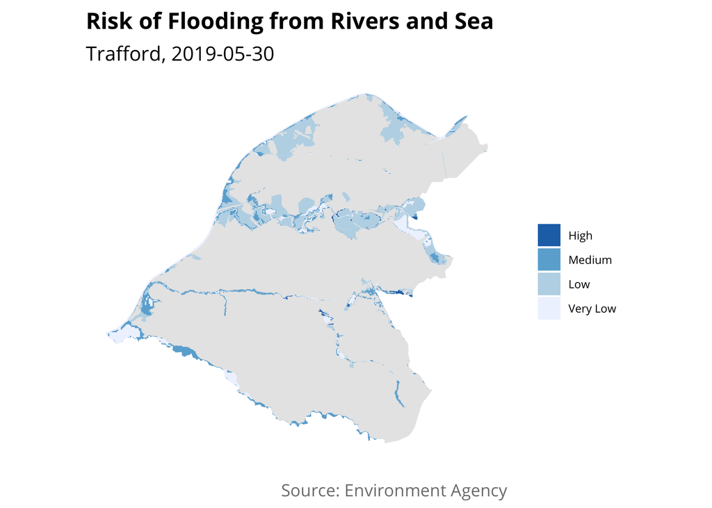

**Additional resources**  
The [Environment Agency](https://www.gov.uk/government/organisations/environment-agency) has an [interactive map](https://flood-warning-information.service.gov.uk/long-term-flood-risk/map) showing flood risk information.

### Air Quality Management Areas

[Air Quality Management Areas](https://uk-air.defra.gov.uk/aqma/) (AQMA) are declared when a local authority expects that air quality will not meet the [National Air Quality Objectives](https://uk-air.defra.gov.uk/assets/documents/National_air_quality_objectives.pdf).

| Indicator | Period | Geography | Source | Updated | Licence | Code |
| --- | --- | --- | --- | --- | --- | --- |
| Air Quality Management Areas | 2019-07 | Raster | [DEFRA](https://uk-air.defra.gov.uk/aqma/maps) | 2019-07 | [OGL v3.0](http://www.nationalarchives.gov.uk/doc/open-government-licence/version/3/) | view |

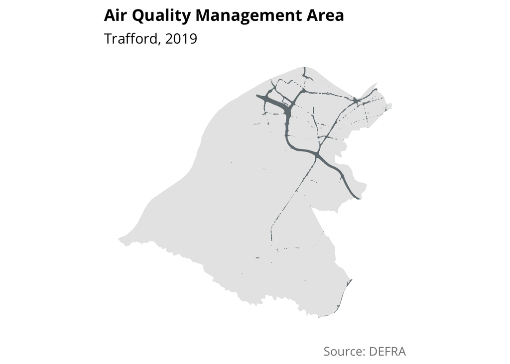

**Additional resources**  
[DEFRA](https://www.gov.uk/government/organisations/department-for-environment-food-rural-affairs) has an [AQMAs interactive map](https://uk-air.defra.gov.uk/aqma/maps).

### Background air pollution

Estimates for annual mean background concentrations of nitrogen oxide (NOx), nitrogen dioxide (NO<sub>2</sub>), coarse (PM<sub>10</sub>) and fine particulate matter (PM<sub>2.5</sub>) are available at 1km x 1km resolution.

| Indicator | Period | Geography | Source | Updated | Licence | Code |
| --- | --- | --- | --- | --- | --- | --- |
| Background air pollution | 2017 | 1 km x 1 km grid square centroids | [DEFRA](https://uk-air.defra.gov.uk/data/laqm-background-maps?year=2017) | 2018-09-27 | [OGL v3.0](http://www.nationalarchives.gov.uk/doc/open-government-licence/version/3/) | view |

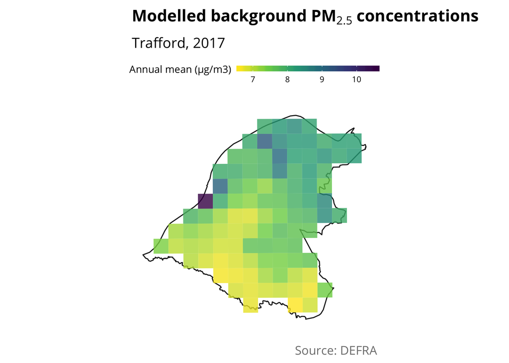

**Additional resources**  
The [UK Ambient Air Quality Interactive Map](https://uk-air.defra.gov.uk/data/gis-mapping) visualises the background concentration data.

### Roadside air pollution

There are several sources of continuous air quality monitoring data including:

- [DEFRA UK-AIR](https://uk-air.defra.gov.uk/data/)
- [Air Quality England](https://www.airqualityengland.co.uk/)
- [Air Quality in Scotland](http://www.scottishairquality.scot/)
- [Air Quality in Wales](https://airquality.gov.wales/)
- [Northern Ireland Air](https://www.airqualityni.co.uk/)
- [OpenAQ](https://openaq.org/#/locations?countries=GB)

The [legal limits](https://ec.europa.eu/environment/air/quality/standards.htm) for NO<sub>2</sub>, PM<sub>10</sub> and PM<sub>2.5</sub> concentrations are:

| Pollutant | Concentration | Averaging period | Permitted exceedences |
| --- | --- | --- | --- |
| NO<sub>2</sub> | 40 µg/m<sup>3</sup> | Annual mean | n/a |
| NO<sub>2</sub> | 200 µg/m<sup>3</sup> | 1-hour mean | 18 times a year |
| PM<sub>10</sub> | 40 µg/m<sup>3</sup> | Annual mean | n/a |
| PM<sub>10</sub> | 50 µg/m<sup>3</sup> | 24-hour mean | 35 times a year |
| PM<sub>2.5</sub> | 25 µg/m<sup>3</sup> | Annual mean | n/a |

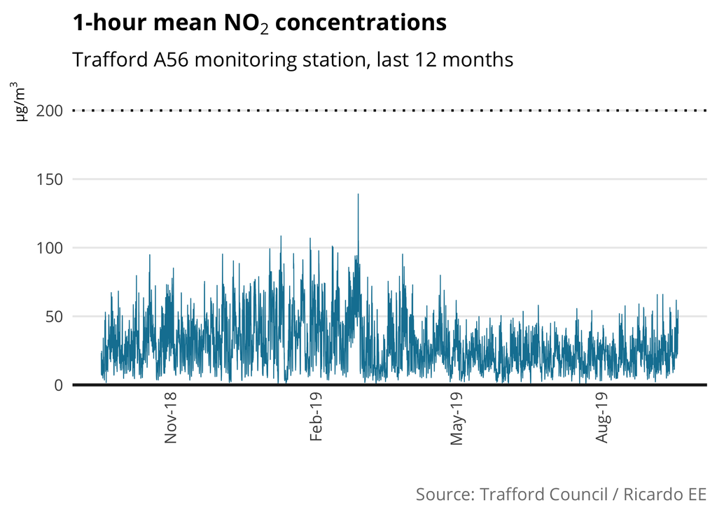

## Mitigation

### Total CO<sub>2</sub> emissions and by sector

Total carbon dioxide emissions are broken down by different domestic, industrial & commercial, and transport sectors. Carbon dioxide emissions are also available per capita (*kt*CO<sub>2</sub>/capita).

| Indicator | Period | Geography | Source | Updated | Licence | Data |
| --- | --- | --- | --- | --- | --- | --- |
| Carbon dioxide emissions | 2005-2017 | Local authority | [BEIS](https://www.gov.uk/government/collections/uk-local-authority-and-regional-carbon-dioxide-emissions-national-statistics) | 2019-06-27 | [OGL v3.0](http://www.nationalarchives.gov.uk/doc/open-government-licence/version/3/) | view |

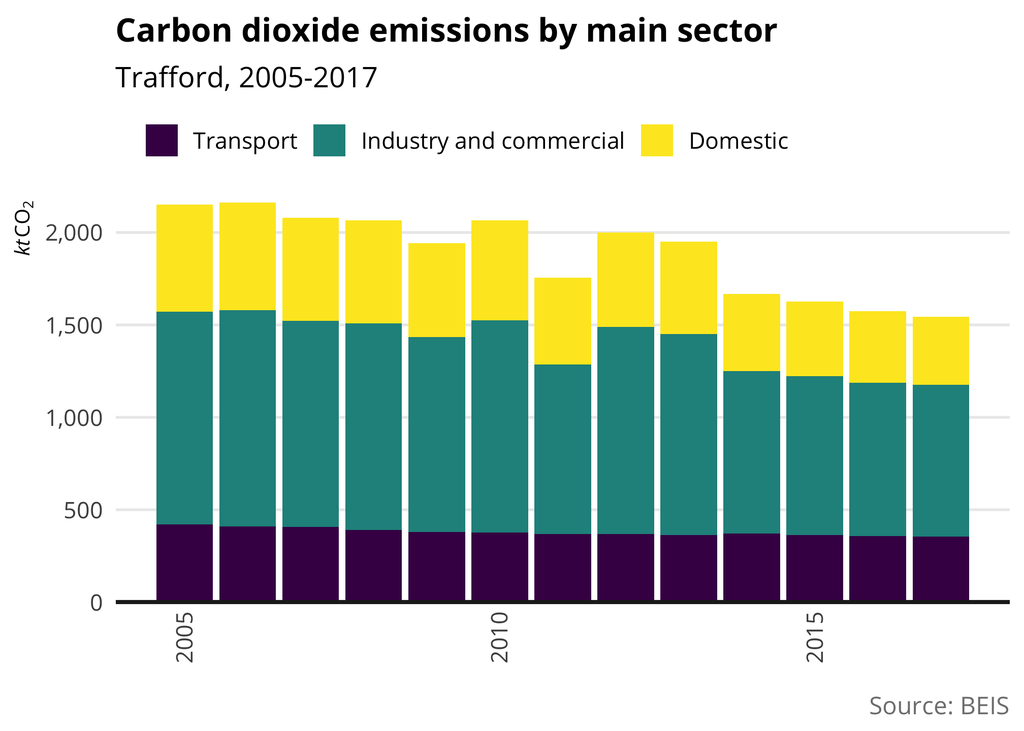

**Additional resources**  
The [National Atmospheric Emissions Inventory](http://naei.defra.gov.uk/) (NAEI) website has an [interactive map](https://naei.beis.gov.uk/laco2app) that allows you to explore CO<sub>2</sub> emissions by local authority area and sector.

### CO<sub>2</sub> emissions from large industrial installations

Carbon dioxide emissions from large industrial installations are available across the UK from the [National Atmospheric Emissions Inventory](http://naei.defra.gov.uk/). Other greenhouse gases such as methane and nitrous oxide are also available.

| Indicator | Period | Geography | Source | Updated | Licence | Data |
| --- | --- | --- | --- | --- | --- | --- |
| CO<sub>2</sub> emissions from large industrial installations | 2016 | Point locations | [NAEI](https://naei.beis.gov.uk/data/map-large-source) | 2018-09-27 | [OGL v3.0](http://www.nationalarchives.gov.uk/doc/open-government-licence/version/3/) | view |

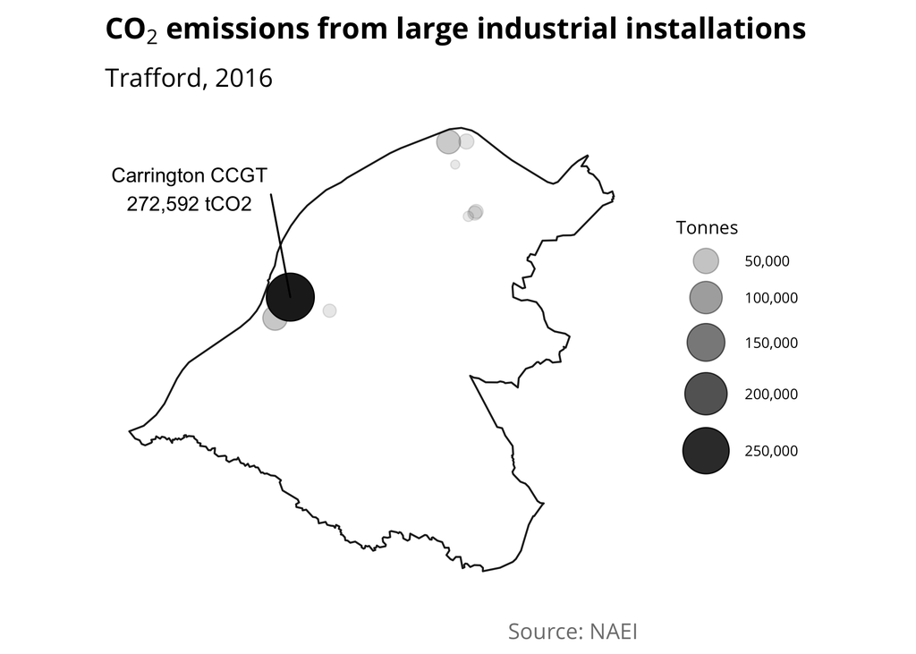

### Road transport fuel consumption

Estimates of road transport fuel use by local authority are available for petrol (petrol cars, motorcycles and petrol LGVs) and diesel (diesel cars, diesel LGVs, HGVs and buses) consuming vehicles. Estimates by road type (motorways, A roads and minor roads) is also available in the source dataset.

| Indicator | Period | Geography | Source | Updated | Licence | Data |
| --- | --- | --- | --- | --- | --- | --- |
| Road transport energy consumption | 2005-2017 | Local authority | [BEIS](https://www.gov.uk/government/statistical-data-sets/road-transport-energy-consumption-at-regional-and-local-authority-level) | 2019-06-27 | [OGL v3.0](http://www.nationalarchives.gov.uk/doc/open-government-licence/version/3/) | view |

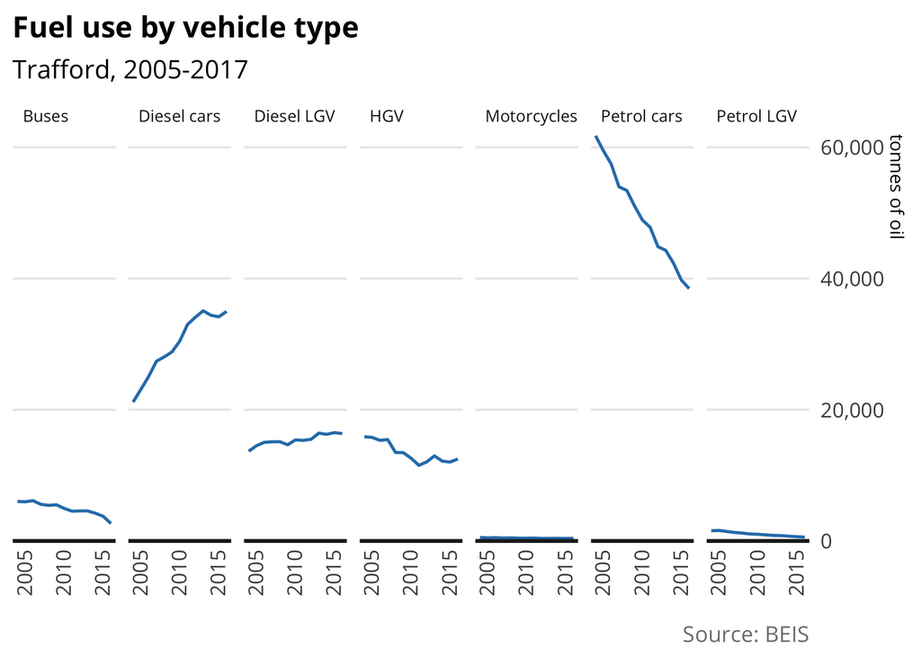

### Domestic property build period

Information about the age of domestic dwellings is available from the [Valuation Office Agency](https://www.gov.uk/government/organisations/valuation-office-agency). The age of a building influences energy consumption with older properties tending to be less energy efficient than newer buildings.

| Indicator | Period | Geography | Source | Updated | Licence | Data |
| --- | --- | --- | --- | --- | --- | --- |
| Domestic property build period | pre-1900 to 2018 | Local authority | [VOA](https://www.gov.uk/government/statistics/council-tax-stock-of-properties-2018) | 2018-11-29 | [OGL v3.0](http://www.nationalarchives.gov.uk/doc/open-government-licence/version/3/) | view |

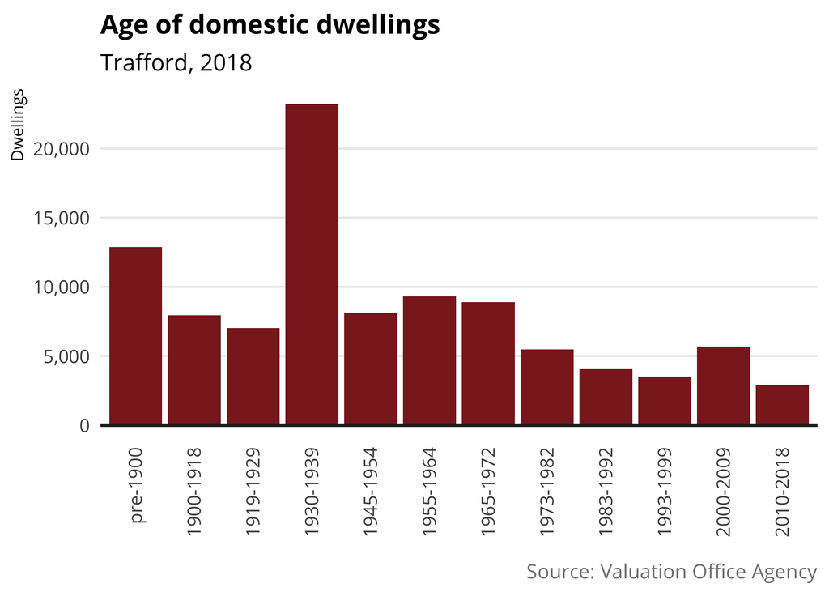

## Adaptation

### Renewable electricity generation

Data on renewable electricity installations, their capacity (MW) and generation (MWh) are available at a local authority level.

| Indicator | Period | Geography | Source | Updated | Licence | Data |
| --- | --- | --- | --- | --- | --- | --- |
| Renewable electricity generation | 2014-2017 | Local authority | [BEIS](https://www.gov.uk/government/statistics/regional-renewable-statistics) | 2018-09-27 | [OGL v3.0](http://www.nationalarchives.gov.uk/doc/open-government-licence/version/3/) | view |

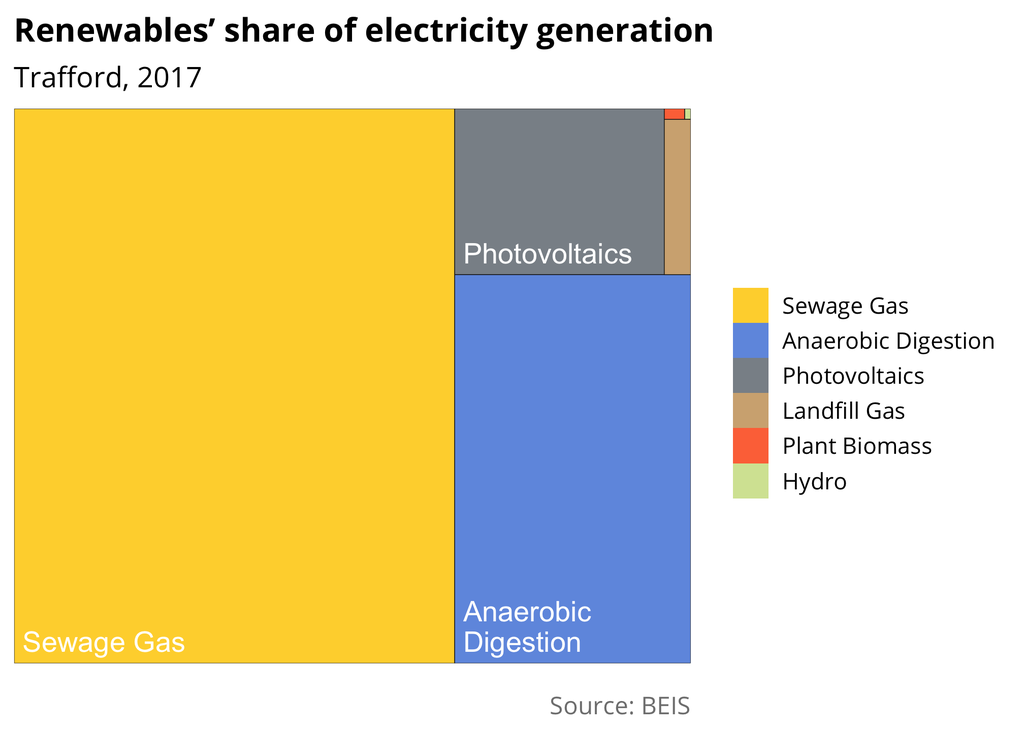

### Recycling

The percentage of household waste sent for reuse, recycling or composting by local councils is available by financial year.

| Indicator | Period | Geography | Source | Updated | Licence | Data |
| --- | --- | --- | --- | --- | --- | --- |
| Recycling | 2010/11 - 2017/18 | Local authority | [DEFRA](https://www.gov.uk/government/statistical-data-sets/env18-local-authority-collected-waste-annual-results-tables) | 2018-12-18 | [OGL v3.0](http://www.nationalarchives.gov.uk/doc/open-government-licence/version/3/) | view |

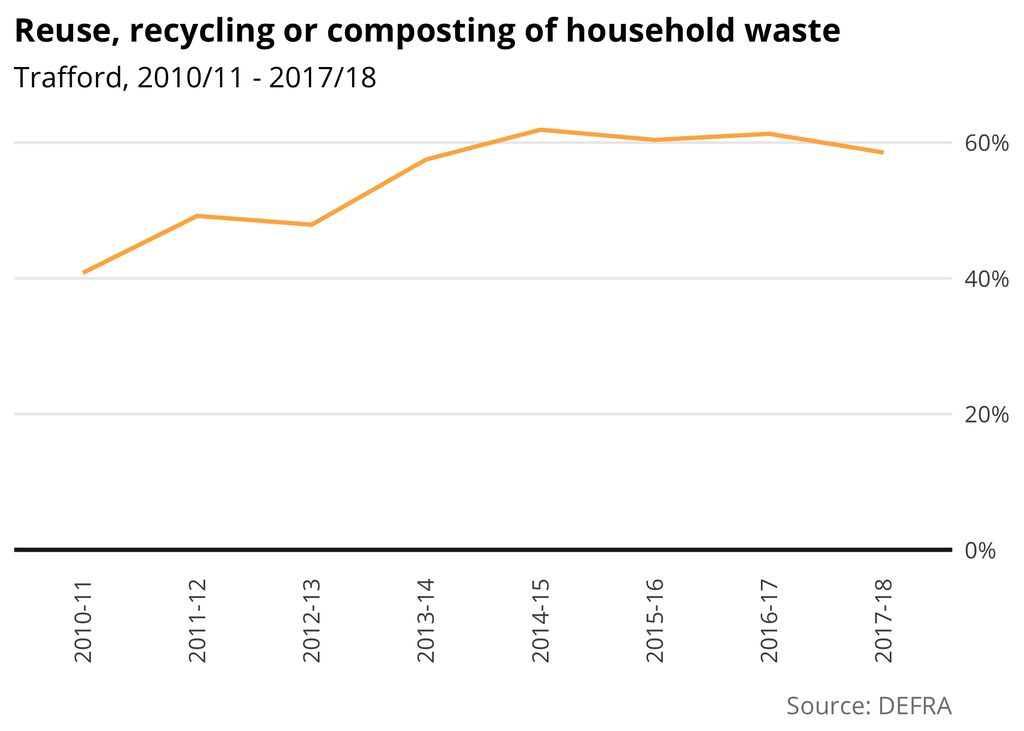

### EPCs by Environmental Impact Rating

An Energy Performance Certificates’ (EPC) Environmental Impact Rating is an estimate of the amount of CO<sub>2</sub> produced by a home. The most energy efficient homes fall within band A (lowest CO<sub>2</sub> emissions) and the least efficent in Band G (highest CO<sub>2</sub> emissions). Lodgements on the Energy Performance of Buildings Register are published on a quarterly basis.

| Indicator | Period | Geography | Source | Updated | Licence | Data |
| --- | --- | --- | --- | --- | --- | --- |
| EPCs by Environmental Impact Rating | 2009-2018 | Local authority | [MHCLG](https://assets.publishing.service.gov.uk/government/uploads/system/uploads/attachment_data/file/821971/D2_-_Domestic_EPCs.xlsx) | 2019-07-31 | [OGL v3.0](http://www.nationalarchives.gov.uk/doc/open-government-licence/version/3/) | view |

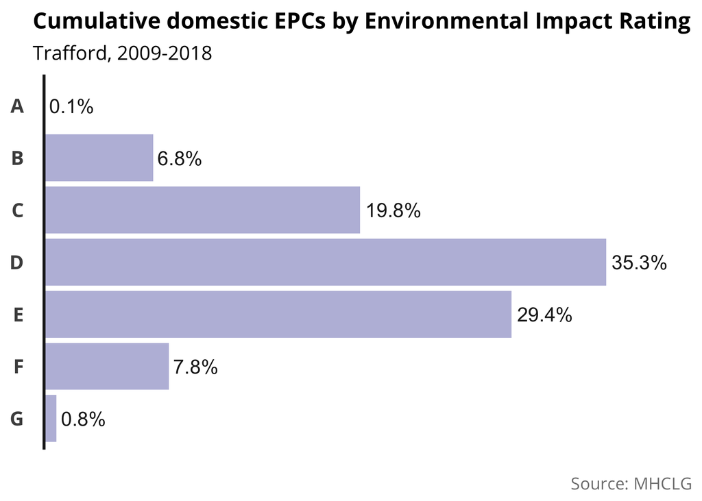

### Licensed electric vehicles

The number of licensed electric vehicles (battery electric, plug-in hybrid electric, or range-extended electric) registered by the keeper’s local authority is published by the Department for Transport. Data on licensed diesel and ultra low emission vehicles (ULEVs) is also available in the source data.

| Indicator | Period | Geography | Source | Updated | Licence | Data |
| --- | --- | --- | --- | --- | --- | --- |
| Licensed electric vehicles | 2011-10-01 - 2019-04-01 | Local authority | [Department for Transport](https://www.gov.uk/government/statistical-data-sets/all-vehicles-veh01) | 2019-09-12 | [OGL v3.0](http://www.nationalarchives.gov.uk/doc/open-government-licence/version/3/) | view |

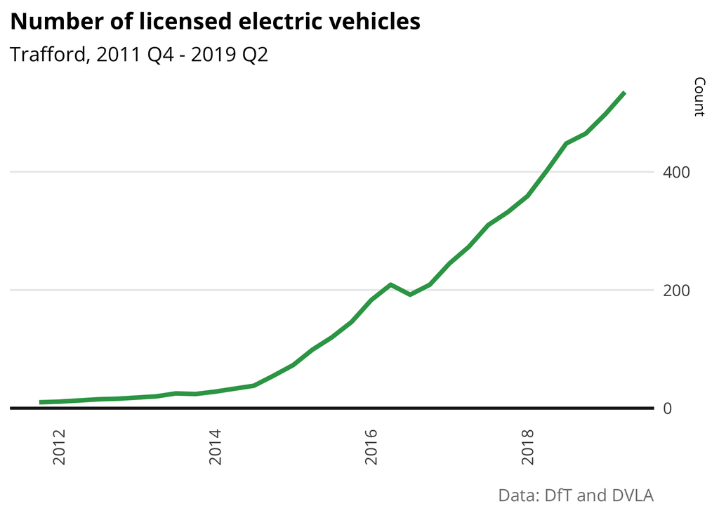

### Cycling

Local authority cycling rates are published by the Department of Transport from the [Active Lives Survey](https://www.sportengland.org/research/active-lives-survey/).

| Indicator | Period | Geography | Source | Updated | Licence | Data |
| --- | --- | --- | --- | --- | --- | --- |
| Cycling | 2017-11 - 2018-11 | Local authority | [Department for Transport](https://www.gov.uk/government/statistical-data-sets/walking-and-cycling-statistics-cw) | 2019-07-31 | [OGL v3.0](http://www.nationalarchives.gov.uk/doc/open-government-licence/version/3/) | view |

The [Active Lives Survey](https://www.sportengland.org/research/active-lives-survey/) estimate that in 2017/18:

- 2.9% of Trafford residents cycle five times a week
- 5.3% of Trafford residents cycle at least three times a week
- 11.1% of Trafford residents cycle at least once a week
- 18.4% of Trafford residents cycle at least once per month

### Walking

Local authority walking rates are published by the Department of Transport from the [Active Lives Survey](https://www.sportengland.org/research/active-lives-survey/).

| Indicator | Period | Geography | Source | Updated | Licence | Data |
| --- | --- | --- | --- | --- | --- | --- |
| Walking | 2017-11 - 2018-11 | Local authority | [Department for Transport](https://www.gov.uk/government/statistical-data-sets/walking-and-cycling-statistics-cw) | 2019-07-31 | [OGL v3.0](http://www.nationalarchives.gov.uk/doc/open-government-licence/version/3/) | view |

The [Active Lives Survey](https://www.sportengland.org/research/active-lives-survey/) estimate that in 2017/18:

- 29.8% of Trafford residents walk five times a week
- 43.5% of Trafford residents walk at least three times a week
- 69.7% of Trafford residents walk at least once a week
- 79.4% of Trafford residents walk at least once per month